# Network Visualization of Breached Internet Services Using HaveIBeenPwned Data

Max Woolf (@minimaxir)

December 19th, 2016

This R Notebook is the complement to my blog post [Network Visualization of Breached Internet Services Using HaveIBeenPwned Data](http://minimaxir.com/2016/12/pwned-network/).

This notebook is licensed under the MIT License. If you use the code or data visualization designs contained within this notebook, it would be greatly appreciated if proper attribution is given back to this notebook and/or myself. Thanks! :)

# 1 Setup

Setup the R packages.

```r
# must install ggnetwork using from source to avoid ggplot2 2.2.0 issue
# install.packages("ggnetwork", type="source")
library(dplyr)
library(readr)
library(igraph)
library(intergraph)
library(sna)
library(ggplot2)
library(ggnetwork)
library(plotly)
library(htmlwidgets)
library(RJSONIO)
```

```r
df <- read_csv('hibp_edges.csv')
df %>% arrange(desc(Weight)) %>% head() %>% print()
```

| Source | Target | Weight |
| --- | --- | --- |
| Adobe | MySpace | 21309458 |
| LinkedIn | MySpace | 18183896 |
| Adobe | LinkedIn | 18160876 |
| Dropbox | LinkedIn | 14562777 |
| NetEase | Tianya | 12830369 |
| MySpace | Tumblr | 12208423 |

There are 10816 edges.

```r
df_totals <- read_csv('hibp_services.csv')
df_totals %>% arrange(desc(Total)) %>% head() %>% print()
```

| Service | Total |
| --- | --- |
| MySpace | 359409507 |
| NetEase | 234841563 |
| LinkedIn | 160074951 |
| Adobe | 152479936 |
| VK | 93338601 |
| Rambler | 91356923 |

There are **1,768,628,867** total records in the dataset. ([expected value](https://www.troyhunt.com/heres-1-4-billion-records-from-have-i-been-pwned-for-you-to-analyse/) should ber # of records - # of records from sensitive breaches: about 1,989,141,353 - 221M = 1,768,141,353))

Combine the two dataframes together; this lets us filter the dataframes using vector operations.

```r
df_merged <- df %>% left_join(df_totals, by = c("Source" = "Service")) %>% left_join(df_totals, by = c("Target" = "Service"))
df_merged %>% arrange(desc(Weight)) %>% tail() %>% print()
```

| Source | Target | Weight | Total.x | Total.y |
| --- | --- | --- | --- | --- |
| HackingTeam | QuantumBooter | 1 | 32310 | 48592 |
| Boxee | Tesco | 1 | 158163 | 2239 |
| Bell | BitTorrent | 1 | 12653 | 34236 |
| IGF | QatarNationalBank | 1 | 3200 | 88678 |
| FoxyBingo | Spirol | 1 | 252216 | 55614 |
| PixelFederation | SprashivaiRu | 1 | 38108 | 3474763 |

Keep only edges with 1% of the proportion in both of the services it connects.

```r
df_merged <- df_merged %>% filter(Weight >= Total.x * 0.01,
                                  Weight >= Total.y * 0.01) %>%
                select(Source, Target, Weight)
df_merged %>% arrange(desc(Weight)) %>% tail() %>% print()
```

| Source | Target | Weight |
| --- | --- | --- |
| MajorGeeks | Malwarebytes | 3183 |
| Boxee | PHPFreaks | 3068 |
| BusinessAcumen | Mac-Torrents | 2978 |
| Boxee | Malwarebytes | 2215 |
| Boxee | BusinessAcumen | 2108 |
| BusinessAcumen | CrackCommunity | 267 |

## 1.1 Breach Data

Get breach data from HaveIBeenPwned for better tooltips.

```r
# http://stackoverflow.com/questions/16947643/getting-imported-json-data-into-a-data-frame-in-r
df_hibp <- fromJSON(content = "https://haveibeenpwned.com/api/v2/breaches")
df_hibp <- do.call("rbind", lapply(df_hibp, as.data.frame))
df_hibp <- df_hibp %>% select(Title, Name, Domain, BreachDate, PwnCount) %>% unique()
df_hibp %>% head() %>% print()
```

|  | Title | Name | Domain | BreachDate | PwnCount |
| --- | --- | --- | --- | --- | --- |
| 1 | 000webhost | 000webhost | 000webhost.com | 2015-03-01 | 13545468 |
| 5 | 126 | 126 | 126.com | 2012-01-01 | 6414191 |
| 7 | 17 | 17Media | 17app.co | 2016-04-19 | 4009640 |
| 12 | Acne.org | AcneOrg | acne.org | 2014-11-25 | 432943 |
| 17 | Adobe | Adobe | adobe.com | 2013-10-04 | 152445165 |
| 21 | Adult Friend Finder | AdultFriendFinder | adultfriendfinder.com | 2015-05-21 | 3867997 |

```r
df_hibp <- df_hibp %>% mutate(text = paste(Title, paste(format(PwnCount, big.mark=",", trim=T), "Pwns"), format(as.Date(BreachDate), "%b %d, %Y"), sep="<br>"))
df_hibp %>% select(text) %>% head() %>% print()
```

|  | text |
| --- | --- |
| 1 | 000webhost13,545,468 PwnsMar 01, 2015 |
| 2 | 1266,414,191 PwnsJan 01, 2012 |
| 3 | 174,009,640 PwnsApr 19, 2016 |
| 4 | Acne.org432,943 PwnsNov 25, 2014 |
| 5 | Adobe152,445,165 PwnsOct 04, 2013 |
| 6 | Adult Friend Finder3,867,997 PwnsMay 21, 2015 |

Build the graph network.

```r
net <- graph.data.frame(df_merged, directed = FALSE)
V(net)$degree <- centralization.degree(net)$res
V(net)$weighted_degree <- graph.strength(net, weights=V(net)$Weight)
V(net)$text <- df_hibp$text[match(V(net)$name, df_hibp$Name)]
net
```

```
IGRAPH UN-- 98 316 --
+ attr: name (v/c), degree (v/n), weighted_degree (v/n), text (v/c),
| Weight (e/n)
+ edges (vertex names):
 [1] WarInc         --WildStar      Dropbox        --iMesh
 [3] MajorGeeks     --Malwarebytes  AndroidForums  --Plex
 [5] GamerzPlanet   --NextGenUpdate VBulletin      --WHMCS
 [7] Aipai          --NetEase       Nival          --WildStar
 [9] Avast          --BlackHatWorld MoDaCo         --Xbox-Scene
[11] CivilOnline    --Tianya        Nihonomaru     --iPmart
[13] Nihonomaru     --WIIUISO       Nival          --XSplit
+ ... omitted several edges
```

```r
V(net)$group <- membership(cluster_walktrap(net, weights=E(net)$Weight))
V(net)$centrality <- eigen_centrality(net, weights=E(net)$Weight)$vector
```

Build the ggnetwork.

```r
# ggnetwork sets default nodes randomly; set seed for reproducibility
set.seed(123)
df_net <- ggnetwork(net, layout = "fruchtermanreingold", weights="Weight", niter=50000)
df_net %>% head() %>% print()
```

|  | x | y | centrality | degree | group | na.x | text | vertex.names | weighted_degree | xend | yend | na.y | Weight |
| --- | --- | --- | --- | --- | --- | --- | --- | --- | --- | --- | --- | --- | --- |
| 1 | 0.4014562 | 0.3382441 | 2.388368e-05 | 11 | 3 | FALSE | War Inc.1,020,136 PwnsJul 04, 2012 | WarInc | 11 | 0.4014562 | 0.3382441 | NA | NA |
| 2 | 0.3937887 | 0.6665694 | 5.999086e-01 | 9 | 10 | FALSE | Dropbox68,648,009 PwnsJul 01, 2012 | Dropbox | 9 | 0.3937887 | 0.6665694 | NA | NA |
| 3 | 0.9449110 | 0.2953051 | 1.005406e-17 | 1 | 17 | FALSE | MajorGeeks269,548 PwnsNov 15, 2015 | MajorGeeks | 1 | 0.9449110 | 0.2953051 | NA | NA |
| 4 | 0.6295837 | 0.4574492 | 7.534162e-06 | 6 | 1 | FALSE | Android Forums745,355 PwnsOct 30, 2011 | AndroidForums | 6 | 0.6295837 | 0.4574492 | NA | NA |
| 5 | 0.4106168 | 0.3031653 | 5.714146e-06 | 9 | 3 | FALSE | Gamerzplanet1,217,166 PwnsOct 23, 2015 | GamerzPlanet | 9 | 0.4106168 | 0.3031653 | NA | NA |
| 6 | 0.6104659 | 0.2182562 | 1.330459e-09 | 9 | 2 | FALSE | vBulletin518,966 PwnsNov 03, 2015 | VBulletin | 9 | 0.6104659 | 0.2182562 | NA | NA |

```r
plot <- ggplot(df_net, aes(x = x, y = y, xend = xend, yend = yend)) +
    geom_edges(aes(alpha = Weight), size=0.25) +
    geom_nodes(aes(fill = as.factor(group), size = degree), shape = 21, color = "#1a1a1a", stroke=0.2) +
    ggtitle("Network Graph of Breaches from HaveIBeenPwned Database (by @minimaxir)") +
    geom_nodelabel_repel(aes(color = as.factor(group), label = vertex.names),
                          family = "Open Sans Condensed Bold", size=1.5, box.padding = unit(0.05, "lines"),
                          label.padding= unit(0.1, "lines"), segment.size=0.1, label.size=0.2) +
    scale_alpha_continuous(range=c(0.1,1)) +
    theme_blank() +
    guides(size=FALSE, color=FALSE, alpha=FALSE, fill=FALSE) +
    theme(plot.title = element_text(family="Source Sans Pro", size=8, hjust=0.5),
            legend.title = element_text(family="Source Sans Pro"),
            legend.text = element_text(family="Source Sans Pro"))
```

```
Ignoring unknown parameters: segment.color
```

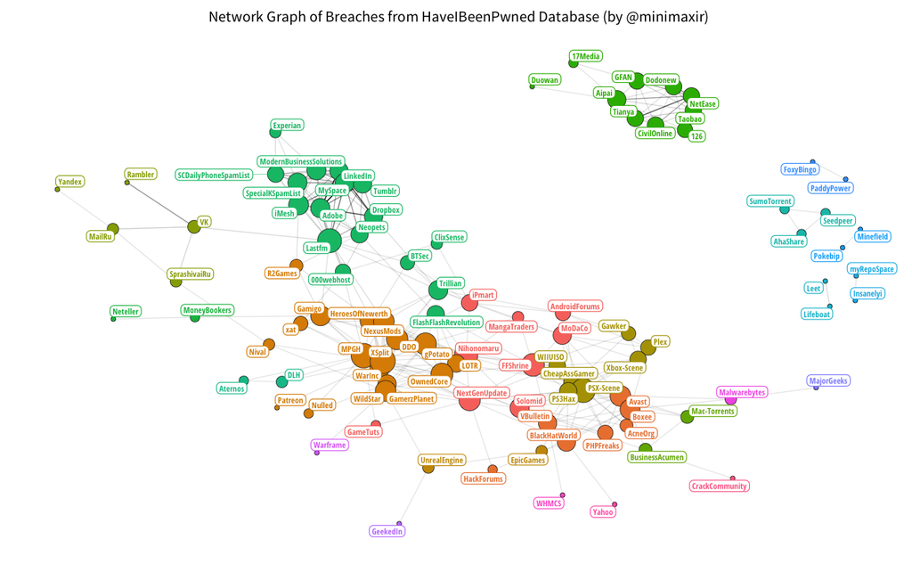

```r
plot
```

```r
ggsave("hibp.png", plot, "png", width=6, height=4.5, dpi=300)
```

## 1.2 Plotly

Make a second graph for more fine-tuned parameters. (and removing `geom_nodelabel_repel`)

In Plotly, `alpha` must be a factor variable due to http://stackoverflow.com/a/37498249. This introduces other bugs, so it was converted to a static value.

```r
plot <- ggplot(df_net, aes(x = x, y = y, xend = xend, yend = yend)) +
    geom_edges(size=0.2, alpha=0.2) +
    geom_nodes(aes(fill = as.factor(group), size = degree, text = text), shape = 21, color = "#1a1a1a", stroke=0.1, text=text) +
    ggtitle("Network Graph of Breaches from HaveIBeenPwned Database (by @minimaxir)") +
    scale_alpha_discrete(range=c(0,0.5)) +
    scale_size_continuous(range=c(2,6)) +
    theme_blank() +
    theme(plot.title = element_text(family="Source Sans Pro", size=10),
            legend.title = element_text(family="Source Sans Pro"),
            legend.text = element_text(family="Source Sans Pro"),
            legend.position="none")
```

```
Ignoring unknown parameters: textIgnoring unknown aesthetics: text
```

```r
plot %>% ggplotly(tooltip="text") %>% toWebGL()
```

[interactive chart not shown]

```r
plot %>% ggplotly(tooltip="text", height=400) %>% toWebGL() %>% saveWidget("hibp-interactive.html", selfcontained=F, libdir="plotly")
```

# 2 LICENSE

The MIT License (MIT)

Copyright (c) 2016 Max Woolf

Permission is hereby granted, free of charge, to any person obtaining a copy of this software and associated documentation files (the “Software”), to deal in the Software without restriction, including without limitation the rights to use, copy, modify, merge, publish, distribute, sublicense, and/or sell copies of the Software, and to permit persons to whom the Software is furnished to do so, subject to the following conditions:

The above copyright notice and this permission notice shall be included in all copies or substantial portions of the Software.

THE SOFTWARE IS PROVIDED “AS IS”, WITHOUT WARRANTY OF ANY KIND, EXPRESS OR IMPLIED, INCLUDING BUT NOT LIMITED TO THE WARRANTIES OF MERCHANTABILITY, FITNESS FOR A PARTICULAR PURPOSE AND NONINFRINGEMENT. IN NO EVENT SHALL THE AUTHORS OR COPYRIGHT HOLDERS BE LIABLE FOR ANY CLAIM, DAMAGES OR OTHER LIABILITY, WHETHER IN AN ACTION OF CONTRACT, TORT OR OTHERWISE, ARISING FROM, OUT OF OR IN CONNECTION WITH THE SOFTWARE OR THE USE OR OTHER DEALINGS IN THE SOFTWARE.